# Assignment3-Sen-WarframeGameReviews

Kushagra Sen

2/11/2020

In this project, we are analyzing the sentiments towrads a game called “Warfare”. The data set has got over 50,000 reviews spread across 4 years. (2016-2019)

The dataset has been taken from Kaggle: https://www.kaggle.com/j457zhan/warframe-steam-user-reviews

```r
warframe<-read.csv("https://drive.google.com/uc?export=download&id=1cO-ejpN8Kg0TsEshMUzrbfCB8FYdO8mg")
head(warframe)
```

```
##   S.No compensation      date early_access found_funny found_helpful
## 1    1            0 4/22/2019        FALSE           0             0
## 2    2            0 4/22/2019        FALSE           0             0
## 3    3            0 4/22/2019        FALSE           0             0
## 4    4            0 4/22/2019        FALSE           0             0
## 5    5            0 4/22/2019        FALSE           0             0
## 6    6            0 4/22/2019        FALSE           0             0
##   found_unhelpful  hours page page_order product_id products recommended
## 1               0 1035.2    1          0     230410        7        TRUE
## 2               0 2397.4    1          1     230410      150        TRUE
## 3               0   16.3    1          2     230410      177        TRUE
## 4               0    9.3    1          4     230410        9        TRUE
## 5               0 1596.1    1          5     230410      132        TRUE
## 6               0   57.1    1          6     230410       10        TRUE
##                                                                                                                                                                                                                                                                                                          …
## 1                                                                                                                                                                                                                                                                       This game took my '1000-hrs-playe…
## 2                                                                                                                                                                                                                                                                                           yea no uther …
## 3                                                                                                                                                                                                                                                                                              We all lif…
## 4                                                                                                                                                                                                                          Good Gameplay only problem is that download of a 500mb update might take up th…
## 5 I think it's arite has it's issues and it's upsides.\nNot for everyone though if you like ing and slaughtering endless hordes of dudes I'd say this might be for you.\nHonestly if you're new and trying this game out I'd recommend getting someone with prior experience to guide you helps a lot.\nO…
## 6                                                                                                                                                                                                                                               One of this games I've seen... They certainly beat all th…
```

We have date written in a format MM/DD/YYYY and we are de-limiting it so that we can evaluate the monthly and yearly trends.

```r
warframe <- warframe %>%
  separate(date
           , into = c("Month", "Date", "Year"), sep = "/")
```

### **Next Step:** Graphical Representation

**Graph 1** This graph shows the overall recommendations (TRUE or FALSE) for the game.

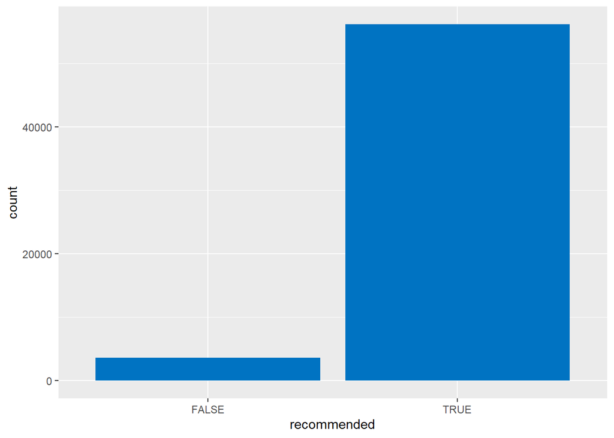

```r
ggplot(warframe, aes(recommended)) +
  geom_bar(fill = "#0073C2FF")
```

Clearly, it has a lot of positive recommendations

**Graph 2** This graph shows the recommendations on an yearly basis (2016-2019)

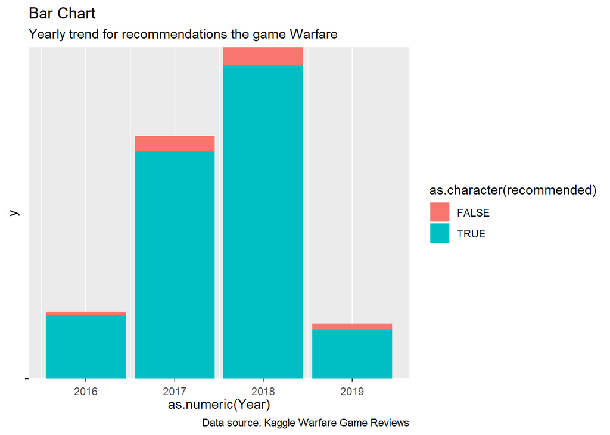

```r
ggplot(warframe, aes(x = as.numeric(Year),y="", fill = as.character(recommended)))+
  geom_bar(stat="identity")+
  labs(title="Bar Chart",
       subtitle="Yearly trend for recommendations the game Warfare",
       caption="Data source: Kaggle Warfare Game Reviews") +
  theme(axis.text.x = element_text(angle=0, vjust=0.2))
```

From this graph we see that there have been very less FALSE recommendations for this game from the time it has been launched

**Graph 3**

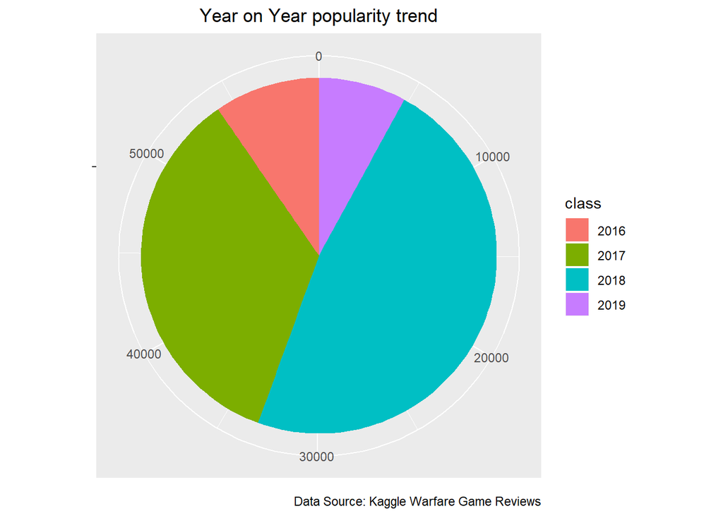

```r
pie <- ggplot(warframe, aes(x = "", fill = factor(Year))) +
  geom_bar(width = 1) +
  theme(axis.line = element_blank(),
        plot.title = element_text(hjust=0.5)) +
  labs(fill="class",
       x=NULL,
       y=NULL,
       title="Year on Year popularity trend",
       caption="Data Source: Kaggle Warfare Game Reviews")
pie + coord_polar(theta = "y", start=0)
```

This shows that year 2018 was the best performing year.

### **Tokenization**

```r
df <- warframe %>% mutate(Text = str_replace_all(text, "(<br />)+", " "))
tokens <- df %>% unnest_tokens(output = word, input = Text)
tokens %>%  dplyr::count(word, sort = TRUE)
```

```
## # A tibble: 35,644 x 2
##    word      n
##    <chr> <int>
##  1 the   73298
##  2 game  61651
##  3 to    59524
##  4 and   56400
##  5 a     48763
##  6 you   39308
##  7 i     38697
##  8 is    37678
##  9 it    35726
## 10 of    35697
## # ... with 35,634 more rows
```

As most of the words are stopwords, we should remove them.

```r
get_stopwords()
```

```
## # A tibble: 175 x 2
##    word      lexicon
##    <chr>     <chr>
##  1 i         snowball
##  2 me        snowball
##  3 my        snowball
##  4 myself    snowball
##  5 we        snowball
##  6 our       snowball
##  7 ours      snowball
##  8 ourselves snowball
##  9 you       snowball
## 10 your      snowball
## # ... with 165 more rows
```

```r
cleaned_tokens <- tokens %>%  anti_join(get_stopwords())
nums <- cleaned_tokens %>% filter(str_detect(word, "^[0-9]")) %>% select(word) %>% unique()
head(nums)
```

```
##    word
## 1  1000
## 2 500mb
## 3     1
## 4     2
## 5     8
## 6    10
```

```r
cleaned_tokens <- cleaned_tokens %>%   anti_join(nums, by = "word")

length(unique(cleaned_tokens$word))
```

```
## [1] 33926
```

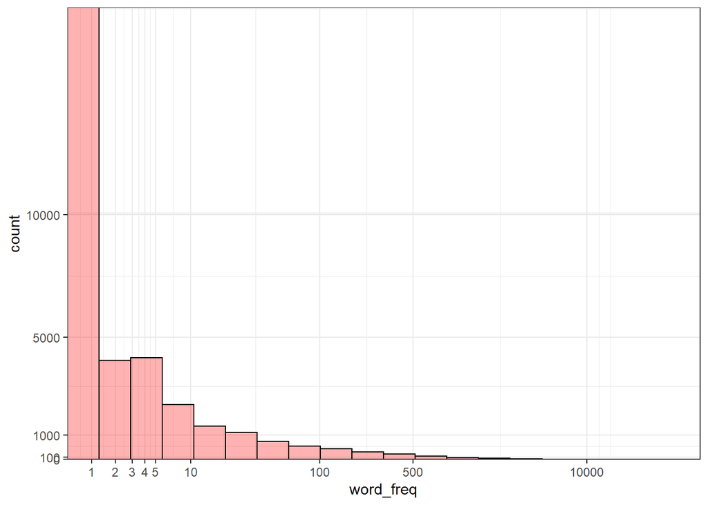

```r
cleaned_tokens %>%   dplyr::count(word, sort = T) %>%  dplyr::rename(word_freq = n) %>%
  ggplot(aes(x=word_freq)) +  geom_histogram(aes(y=..count..), color="black", fill="red", alpha=0.3, bins=20) +  scale_x_continuous(breaks=c(0:5,10,100,500,10e3), trans="log1p", expand=c(0,0)) +  scale_y_continuous(breaks=c(0,100,1000,5e3,10e3,5e4,10e4,4e4), expand=c(0,0)) +  theme_bw()
```

So it makes sense to remove rare words to improve the performance of text analytics. Let’s remove words that have less than 10 appearances in our collection:

```r
rare <- cleaned_tokens %>%   dplyr::count(word) %>%  filter(n<10) %>%  select(word) %>% unique()

cleaned_tokens <- cleaned_tokens %>%   anti_join(rare, by = "word")

length(unique(cleaned_tokens$word))
```

```
## [1] 5320
```

### **Word Cloud**

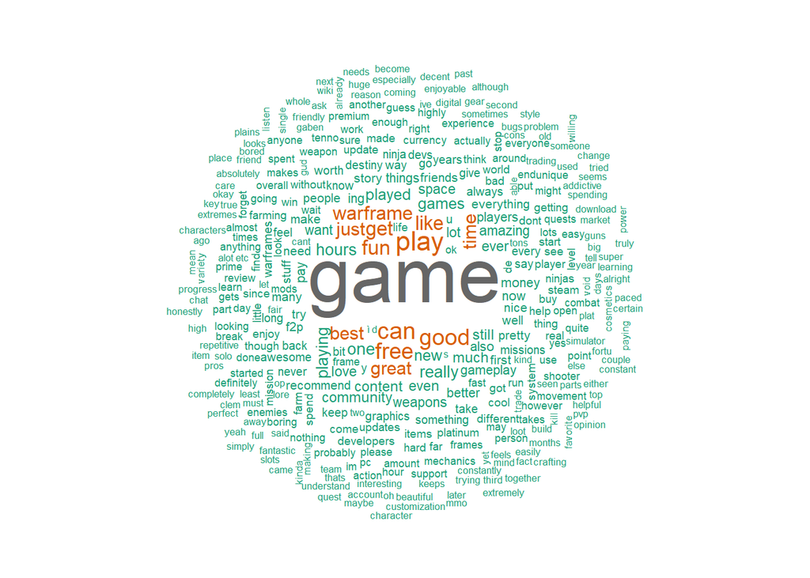

```r
pal <- brewer.pal(8,"Dark2")

cleaned_tokens %>%   dplyr::count(word) %>%  with(wordcloud(word, n, random.order = FALSE, max.words =350, colors=pal))
```

### **Sentiment Analysis**

```r
get_sentiments("nrc")
```

```
## # A tibble: 13,901 x 2
##    word        sentiment
##    <chr>       <chr>
##  1 abacus      trust
##  2 abandon     fear
##  3 abandon     negative
##  4 abandon     sadness
##  5 abandoned   anger
##  6 abandoned   fear
##  7 abandoned   negative
##  8 abandoned   sadness
##  9 abandonment anger
## 10 abandonment fear
## # ... with 13,891 more rows
```

```r
get_sentiments("afinn")
```

```
## # A tibble: 2,477 x 2
##    word       value
##    <chr>      <dbl>
##  1 abandon       -2
##  2 abandoned     -2
##  3 abandons      -2
##  4 abducted      -2
##  5 abduction     -2
##  6 abductions    -2
##  7 abhor         -3
##  8 abhorred      -3
##  9 abhorrent     -3
## 10 abhors        -3
## # ... with 2,467 more rows
```

```r
get_sentiments("bing")
```

```
## # A tibble: 6,786 x 2
##    word        sentiment
##    <chr>       <chr>
##  1 2-faces     negative
##  2 abnormal    negative
##  3 abolish     negative
##  4 abominable  negative
##  5 abominably  negative
##  6 abominate   negative
##  7 abomination negative
##  8 abort       negative
##  9 aborted     negative
## 10 aborts      negative
## # ... with 6,776 more rows
```

```r
sent_reviews = cleaned_tokens %>%
  left_join(get_sentiments("nrc")) %>%
  rename(nrc = sentiment) %>%
  left_join(get_sentiments("bing")) %>%
  rename(bing = sentiment) %>%
  left_join(get_sentiments("afinn")) %>%
  rename(afinn = value)
head(sent_reviews,5)
```

```
##   S.No compensation Month Date Year early_access found_funny found_helpful
## 1    1            0     4   22 2019        FALSE           0             0
## 2    1            0     4   22 2019        FALSE           0             0
## 3    1            0     4   22 2019        FALSE           0             0
## 4    1            0     4   22 2019        FALSE           0             0
## 5    2            0     4   22 2019        FALSE           0             0
##   found_unhelpful  hours page page_order product_id products recommended
## 1               0 1035.2    1          0     230410        7        TRUE
## 2               0 1035.2    1          0     230410        7        TRUE
## 3               0 1035.2    1          0     230410        7        TRUE
## 4               0 1035.2    1          0     230410        7        TRUE
## 5               0 2397.4    1          1     230410      150        TRUE
##                                             text   word  nrc bing afinn
## 1 This game took my '1000-hrs-played' virginity.   game <NA> <NA>    NA
## 2 This game took my '1000-hrs-played' virginity.   took <NA> <NA>    NA
## 3 This game took my '1000-hrs-played' virginity.    hrs <NA> <NA>    NA
## 4 This game took my '1000-hrs-played' virginity. played <NA> <NA>    NA
## 5                     yea no uther trash play it    yea <NA> <NA>    NA
```

### **Most common positive and negative words**

```r
bing_word_counts <- sent_reviews %>%  filter(!is.na(bing)) %>%  dplyr::count(word, bing, sort = TRUE)
head(bing_word_counts,10)
```

```
## # A tibble: 10 x 3
##    word   bing         n
##    <chr>  <chr>    <int>
##  1 good   positive 61815
##  2 fun    positive 29088
##  3 free   positive 12052
##  4 pretty positive 11832
##  5 like   positive  9526
##  6 love   positive  9318
##  7 best   positive  8471
##  8 bad    negative  8285
##  9 great  positive  8069
## 10 enjoy  positive  6668
```

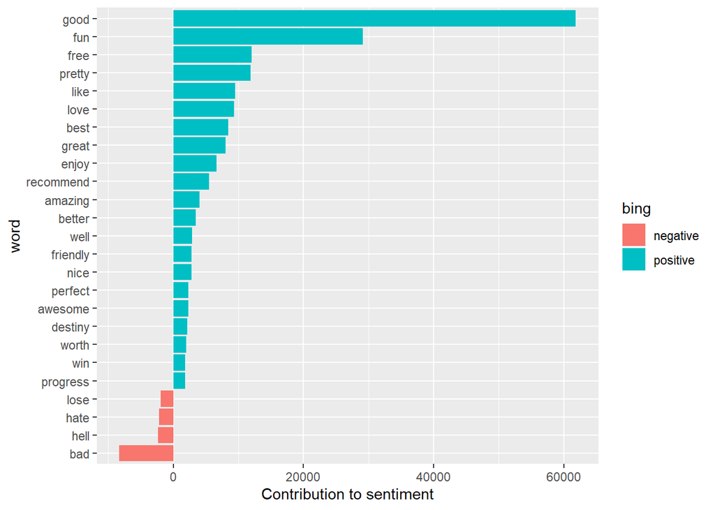

```r
bing_word_counts %>%  filter(n > 1800) %>%  mutate(n = ifelse(bing == "negative", -n, n)) %>%
  mutate(word = reorder(word, n)) %>%  ggplot(aes(word, n, fill = bing)) +  geom_col() +  coord_flip() +  labs(y = "Contribution to sentiment")
```

Above plot shows the positive and negative words and, their contribution to the overall sentiment

Now, tokenizing by n-gram

```r
df$text<-as.character(df$text)
bigrams <- df %>%  unnest_tokens(bigram, Text, token = "ngrams", n = 2)
```

```r
bigrams %>%  dplyr::count(bigram, sort = TRUE)
```

```
## # A tibble: 383,685 x 2
##    bigram        n
##    <chr>     <int>
##  1 this game 19327
##  2 the game  12750
##  3 to play    8782
##  4 game is    7786
##  5 of the     7710
##  6 if you     6724
##  7 you can    5951
##  8 the best   5076
##  9 free to    5009
## 10 is a       4542
## # ... with 383,675 more rows
```

### **Most common bigrams**

```r
bigrams %>%
count(bigram, sort = TRUE)
```

```
## # A tibble: 383,685 x 2
##    bigram        n
##    <chr>     <int>
##  1 this game 19327
##  2 the game  12750
##  3 to play    8782
##  4 game is    7786
##  5 of the     7710
##  6 if you     6724
##  7 you can    5951
##  8 the best   5076
##  9 free to    5009
## 10 is a       4542
## # ... with 383,675 more rows
```

```r
head(bigrams,5)
```

```
##   S.No compensation Month Date Year early_access found_funny found_helpful
## 1    1            0     4   22 2019        FALSE           0             0
## 2    1            0     4   22 2019        FALSE           0             0
## 3    1            0     4   22 2019        FALSE           0             0
## 4    1            0     4   22 2019        FALSE           0             0
## 5    1            0     4   22 2019        FALSE           0             0
##   found_unhelpful  hours page page_order product_id products recommended
## 1               0 1035.2    1          0     230410        7        TRUE
## 2               0 1035.2    1          0     230410        7        TRUE
## 3               0 1035.2    1          0     230410        7        TRUE
## 4               0 1035.2    1          0     230410        7        TRUE
## 5               0 1035.2    1          0     230410        7        TRUE
##                                             text    bigram
## 1 This game took my '1000-hrs-played' virginity. this game
## 2 This game took my '1000-hrs-played' virginity. game took
## 3 This game took my '1000-hrs-played' virginity.   took my
## 4 This game took my '1000-hrs-played' virginity.   my 1000
## 5 This game took my '1000-hrs-played' virginity.  1000 hrs
```

### **Filtering n-grams**

```r
bigrams_separated <- bigrams %>%
  separate(bigram, c("word1", "word2"), sep = " ")
bigrams_filtered <- bigrams_separated %>%
  filter(!word1 %in% stop_words$word) %>%
  filter(!word2 %in% stop_words$word)
bigrams_filtered <- bigrams_filtered %>% drop_na()
bigrams_filtered %>% count(word1, word2, sort = TRUE)
```

```
## # A tibble: 111,466 x 3
##    word1   word2        n
##    <chr>   <chr>    <int>
##  1 10      10        2333
##  2 play    game      1968
##  3 free    game      1233
##  4 space   ninja     1200
##  5 fun     game      1147
##  6 f2p     game       991
##  7 space   ninjas     938
##  8 amazing game       872
##  9 gaben   gaben      798
## 10 premium currency   775
## # ... with 111,456 more rows
```

```r
head(bigrams_filtered,5)
```

```
##   S.No compensation Month Date Year early_access found_funny found_helpful
## 1    1            0     4   22 2019        FALSE           0             0
## 2    1            0     4   22 2019        FALSE           0             0
## 3    1            0     4   22 2019        FALSE           0             0
## 4    2            0     4   22 2019        FALSE           0             0
## 5    2            0     4   22 2019        FALSE           0             0
##   found_unhelpful  hours page page_order product_id products recommended
## 1               0 1035.2    1          0     230410        7        TRUE
## 2               0 1035.2    1          0     230410        7        TRUE
## 3               0 1035.2    1          0     230410        7        TRUE
## 4               0 2397.4    1          1     230410      150        TRUE
## 5               0 2397.4    1          1     230410      150        TRUE
##                                             text  word1     word2
## 1 This game took my '1000-hrs-played' virginity.   1000       hrs
## 2 This game took my '1000-hrs-played' virginity.    hrs    played
## 3 This game took my '1000-hrs-played' virginity. played virginity
## 4                     yea no uther trash play it  uther     trash
## 5                     yea no uther trash play it  trash      play
```

### **New Bigrams**

```r
bigrams_filtered %>%   dplyr::count(word1, word2, sort = TRUE)
```

```
## # A tibble: 111,466 x 3
##    word1   word2        n
##    <chr>   <chr>    <int>
##  1 10      10        2333
##  2 play    game      1968
##  3 free    game      1233
##  4 space   ninja     1200
##  5 fun     game      1147
##  6 f2p     game       991
##  7 space   ninjas     938
##  8 amazing game       872
##  9 gaben   gaben      798
## 10 premium currency   775
## # ... with 111,456 more rows
```

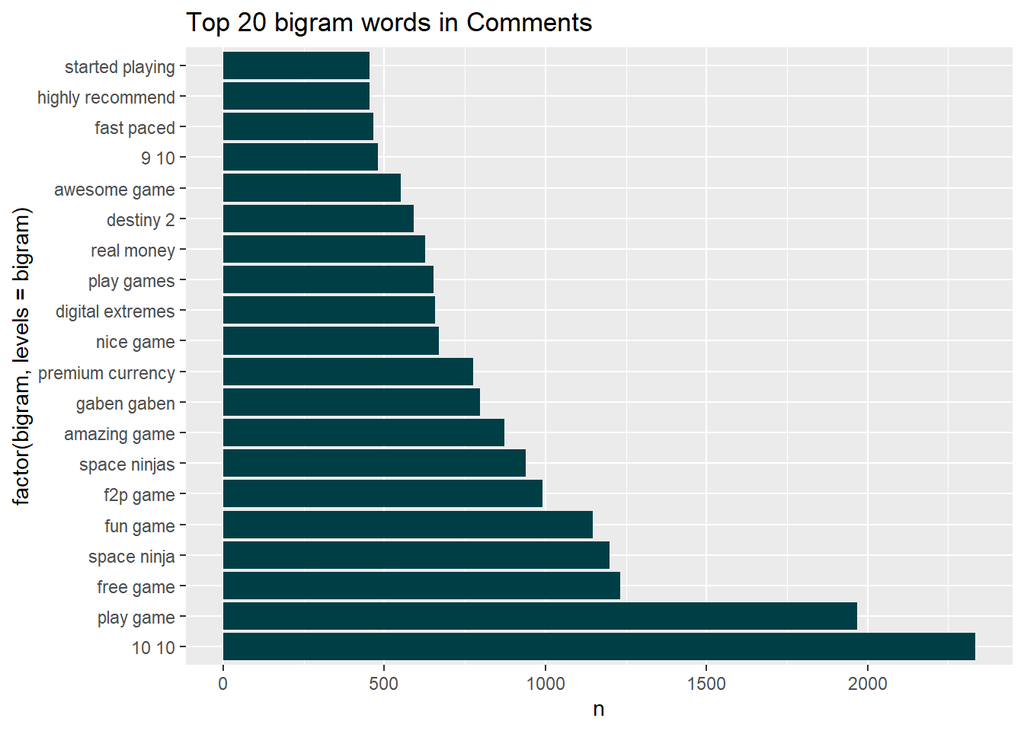

```r
bigram_united <- bigrams_filtered %>%
  unite(bigram, word1, word2, sep = " ")

bigram_counts <- bigram_united %>%
  dplyr::count(bigram, sort = TRUE)

bigram_counts %>% arrange(desc(n))%>% head(20)%>%ggplot(aes(x=factor(bigram,levels=bigram),y=n))+geom_bar(stat="identity",fill="#003E45")+labs(title="Top 20 bigram words in Comments")+coord_flip()
```

The popular Bigram is (10 10) which means 10/10 as we have removed the “/” sign.

### **Word correlations**

```r
rare <- cleaned_tokens %>%
  count(word) %>%
  filter(n<1000) %>% #remove rare words
  # < 1000 reviews
  select(word) %>% distinct()
word_cor <- cleaned_tokens %>%
  filter(!word %in% rare$word) %>%
  widyr::pairwise_cor(word, S.No) %>%
  filter(!is.na(correlation),
         correlation > .25)
head(word_cor,5)
```

```
## # A tibble: 5 x 3
##   item1   item2  correlation
##   <chr>   <chr>        <dbl>
## 1 ever    played       0.281
## 2 free    play         0.443
## 3 can     play         0.255
## 4 feel    like         0.263
## 5 players new          0.333
```

### **Visualizing the correlations**

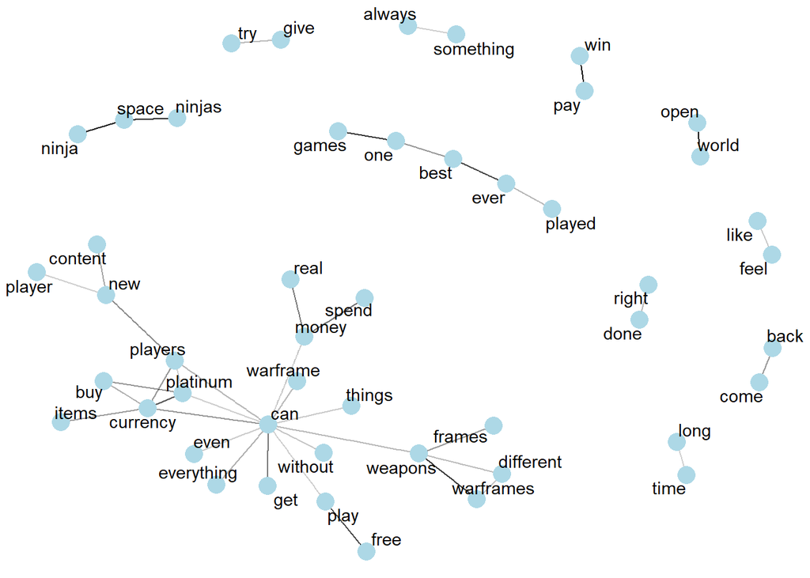

```r
library(igraph)
library(ggraph)
word_cor %>%
graph_from_data_frame() %>%
ggraph(layout = "fr") +
geom_edge_link(aes(edge_alpha = correlation), show.legend = FALSE) +
geom_node_point(color = "lightblue", size = 5) +
geom_node_text(aes(label = name), repel = TRUE) +
theme_void()
```

### **Document Term Matrix**

tf-idf is Term Frequency and Inverse document frequency. Using this, We can see the repititon of a term in a document and as compared to overall frequency of document.

```r
word_counts_by_SNo <- cleaned_tokens %>%
  group_by(S.No) %>%
  dplyr::count(word, sort = TRUE)
word_counts_by_SNo
```

```
## # A tibble: 809,481 x 3
## # Groups:   S.No [57,877]
##     S.No word        n
##    <int> <chr>   <int>
##  1 20138 u        1439
##  2 51799 gaben     799
##  3 22504 ì         225
##  4 44952 blood     195
##  5 44952 covered   195
##  6 44952 forget    195
##  7 44952 return    195
##  8 32389 ì         169
##  9 51601 farm      153
## 10  3844 hey       120
## # ... with 809,471 more rows
```

```r
review_dtm <- word_counts_by_SNo %>%
cast_dtm(S.No, word, n)
```

```r
tfidf <- word_counts_by_SNo %>%
  bind_tf_idf(word, S.No, n)
head(tfidf,5)
```

```
## # A tibble: 5 x 6
## # Groups:   S.No [4]
##    S.No word        n    tf   idf tf_idf
##   <int> <chr>   <int> <dbl> <dbl>  <dbl>
## 1 20138 u        1439 1      4.42   4.42
## 2 51799 gaben     799 1      8.89   8.89
## 3 22504 ì         225 0.623  7.97   4.97
## 4 44952 blood     195 0.25   7.05   1.76
## 5 44952 covered   195 0.25   7.79   1.95
```

These are the TOP tf-idf in descending order

```r
top_tfidf <- tfidf %>%
  group_by(S.No) %>%
  arrange(desc(tf_idf)) %>%
  top_n(3) %>% ungroup() %>%
  arrange(S.No, -tf_idf)
head(top_tfidf,10)
```

```
## # A tibble: 10 x 6
##     S.No word         n    tf   idf tf_idf
##    <int> <chr>    <int> <dbl> <dbl>  <dbl>
##  1     1 hrs          1 0.25   5.62  1.41
##  2     1 took         1 0.25   5.23  1.31
##  3     1 played       1 0.25   2.51  0.627
##  4     2 yea          1 0.333  6.47  2.16
##  5     2 trash        1 0.333  5.70  1.90
##  6     2 play         1 0.333  1.62  0.539
##  7     3 lift         1 0.5    6.02  3.01
##  8     3 together     1 0.5    4.90  2.45
##  9     4 problem      1 0.125  4.71  0.589
## 10     4 download     1 0.125  4.57  0.571
```

Now creating a 4 topic LDA model:

```r
lda5 <- LDA(review_dtm, k = 4, control = list(seed = 1234))
terms(lda5, 10)
```

```
##       Topic 1    Topic 2  Topic 3    Topic 4
##  [1,] "can"      "game"   "game"     "game"
##  [2,] "get"      "play"   "just"     "good"
##  [3,] "warframe" "free"   "hours"    "like"
##  [4,] "weapons"  "fun"    "playing"  "love"
##  [5,] "like"     "best"   "warframe" "amazing"
##  [6,] "players"  "great"  "still"    "space"
##  [7,] "things"   "games"  "new"      "pretty"
##  [8,] "money"    "one"    "time"     "better"
##  [9,] "want"     "really" "content"  "recommend"
## [10,] "also"     "ever"   "even"     "u"
```